# HW3 PART A

RIBÓ & SOFIANOS

31 de enero de 2019

In view of Markov condition, joint probability portrayed in DAGs is:

$$p(x_{1},x_{2},x_{3},x_{4},x_{5},x_{6})=p(x_{1}) \times p(x_{2}|x_{1}) \times p(x_{3}|x_{1}) \times p(x_{4}|x_{2}) \times p(x_{5}|x_{3}) \times p(x_{6}|x_{2},x_{5})$$

When all is said in done, to check if a $\begin{aligned} \{X_{A} \perp \!\!\! \perp X_{B} | X_{C} \}\end{aligned}$ is valid, we can burn through each node in A,do a depthâfirst pursuit to achieve each node in B, and inspect the path

between them. On the off chance that the majority of the paths are blocked, $\begin{aligned} X_{A} \end{aligned}$ is said to be dâseparated from $\begin{aligned} X_{B} \end{aligned}$ by $\begin{aligned} X_{C} \end{aligned}$, at that point we can declare that conditional indepencence proclamation is valid.

Path is blocked in the event that it incorporates a node with the end goal that either:

A)The bolts on the path meet either **head-to-tail** or **tail-to-tail** at the node, and the **node is a piece of the conditioning set $\begin{aligned} X_{C} \end{aligned}$** , or

B)The bolts meet **head-to-head** at the node, and **neither the node, nor any of its relatives, is in the set $\begin{aligned} X_{C} \end{aligned}$** In our model, to check if connection (1) holds we have following accessible #paths between $\begin{aligned} X_{2} \end{aligned}$ and $\begin{aligned} X_{3} \end{aligned}$:

1. $\begin{aligned} X_{2} \end{aligned}$ - $\begin{aligned} X_{1} \end{aligned}$ - $\begin{aligned} X_{3} \end{aligned}$

The bolts on the path meet tailâtoâtail at the hub $\begin{aligned} X_{1}\end{aligned}$ which has a place with the conditioning set $\begin{aligned} \{ X_{1}, X_{6} \} \end{aligned}$. Consequently, path is blocked.

2. $\begin{aligned} X_{2} \end{aligned}$ - $\begin{aligned} X_{6} \end{aligned}$ - $\begin{aligned} X_{5} \end{aligned}$ - $\begin{aligned} X_{3} \end{aligned}$

The arrows meet head-to-head at the node $\begin{aligned} X_{6} \end{aligned}$ however it has a place with the conditioning set (definition part b not fulfilled).

The arrows meet head-to-tail at the node $\begin{aligned} X_{5} \end{aligned}$ however it doesn’t have a place with the conditioning set (definition section a).

Hence, path isn’t blocked.

Considering that not all the paths are blocked, we inferred that $\begin{aligned} \{X_{2} \perp \!\!\! \perp X_{3} | X_{1},X_{6} \}\end{aligned}$ is **not true**.

To check if relation (2) holds we have following accessible paths between $\begin{aligned} X_{1} \end{aligned}$ and $\begin{aligned} X_{6} \end{aligned}$:

1.$\begin{aligned} X_{1} \end{aligned}$ - $\begin{aligned} X_{2} \end{aligned}$ - $\begin{aligned} X_{6} \end{aligned}$

The bolts on the path meet headâtoâtail at the node $\begin{aligned} X_{2}\end{aligned}$ which has a place with the conditioning set $\begin{aligned} \{ X_{2}, X_{3} \} \end{aligned}$. In this manner, path is blocked.

2.$\begin{aligned} X_{1} \end{aligned}$ - $\begin{aligned} X_{3} \end{aligned}$ - $\begin{aligned} X_{5} \end{aligned}$ - $\begin{aligned} X_{6} \end{aligned}$

The bolts meet head-to-tail at the node $\begin{aligned} X_{3} \end{aligned}$ which has a place with the conditioning set. In this manner, path is blocked.

Considering that all the paths are blocked, we presumed that $\begin{aligned} \{X_{1} \perp \!\!\! \perp X_{6} | X_{2},X_{3} \}\end{aligned}$ is **true**.

By the meaning of conditional independence, from connection (2), we have:

$$p(x_{1},x_{6}|x_{2},x_{3})=p(x_{1}|x_{2},x_{3}) \times p(x_{6}|x_{2},x_{3})$$
By the meaning of conditional probability:

$$p(x_{1},x_{6}|x_{2},x_{3})=\frac{p(x_{1},x_{2},x_3,x_{6})}{p(x_{2},x_{3})}(2)$$

Also,

$$p(x_{1}|x_{2},x_{3})=\frac{p(x_{1},x_{2},x_3)}{p(x_{2},x_{3})}(3)$$

Supplanting numerator and denominator in condition (1) with conditions (2) and (3), individually, we get:

$$p(x_{6}|x_{2},x_{3})=\frac{p(x_{1},x_{2},x_{3},x_{6})}{p(x_{1},x_{2},x_{3})}(4)$$

By the meaning of conditional probability:

$$p(x_{6}|x_{1},x_{2},x_{3})=\frac{p(x_{1},x_{2},x_{3},x_{6})}{p(x_{1},x_{2},x_{3})}(5)$$

From (4) and (5) we demonstrated that:

$$p(x_{6}|x_{1},x_{2},x_{3})=p(x_{6}|x_{2},x_{3})$$

where, conditionally on $\begin{aligned} \mu = [\mu_{1}, \mu_{2}] \end{aligned}$ and $\begin{aligned} \sigma^2\end{aligned}$, we accept that:

- $\begin{aligned} \textrm{ X } =[X_{1},X_{2}]^{T} \sim N_{2}(\mu,\sigma^2I_{2})\end{aligned}$
- $\begin{aligned} \textrm{ Y } =[Y_{1},Y_{2}]^{T} \sim N_{2}(\mu,\sigma^2I_{2})\end{aligned}$

1.Joint distribution relating to this DAG is:

$$f(\mu,\sigma^2,X_{1},X_{2},Y_{1},Y_{2})=f(\mu) \times f(\sigma^2) \times f(X_{1}|\mu, \sigma^2) \times f(X_{2}|\mu, \sigma^2,X_{1}) \times f(Y_{1}|\mu, \sigma^2) \times f(Y_{2}|\mu, \sigma^2,Y_{1}))$$

Variance-Covariance Matrix for X and Y, given random variables with bivariate normal distribution is:

From variance-covariance matrix, covariance between $\begin{aligned} X_{1} \end{aligned}$ and $\begin{aligned} X_{2} \end{aligned}$ which is characterized as $\begin{aligned} \sigma^2 \times \rho \end{aligned}$ for some constant $\begin{aligned} \rho \end{aligned}$ is 0. Since $\begin{aligned} \sigma^2 > 0 \end{aligned}$, therfore, $\begin{aligned} \rho \end{aligned}$ is 0.

PDF for bivariate normal distribution of X, given $\begin{aligned} \mu \end{aligned}$ and $\begin{aligned} \sigma^2 \end{aligned}$ is:

$$f_{X_{1},X_{2}|\mu,\sigma^2}(x_{1},x_{2})=\frac{1}{2\pi\sigma^2} \times \exp(- \frac{(x_{1}-\mu_{1})^2+(x_{2}-\mu_{2})^2}{2\sigma^2} )$$

From the meaning of conditional probability and considering that coefficient $\begin{aligned} \rho =0 \end{aligned}$, we get:

$$f_{X_{2}|\mu,\sigma^2,X_{1}}(x_{1}|x_{2})=\frac{1}{\sqrt{2\pi\sigma^2}} \times \exp(- \frac{(x_{2}-\mu_{2})^2}{2\sigma^2} )=f_{X_{2}|\mu,\sigma^2}(x_{2})$$

Same standard applies on random variable Y, hence:

$$f_{Y_{1},Y_{2}|\mu,\sigma^2}(y_{1},y_{2})=\frac{1}{2\pi\sigma^2} \times \exp(- \frac{(y_{1}-\mu_{1})^2+(y_{2}-\mu_{2})^2}{2\sigma^2} )$$

$$f_{Y_{2}|\mu,\sigma^2,Y_{1}}(y_{1}|y_{2})=\frac{1}{\sqrt{2\pi\sigma^2}} \times \exp(- \frac{(y_{2}-\mu_{2})^2}{2\sigma^2} )=f_{Y_{2}|\mu,\sigma^2}(y_{2})$$

Joint distribution relating to this DAG could be then re-composed as:

$$f(\mu,\sigma^2,X_{1},X_{2},Y_{1},Y_{2})=f(\mu) \times f(\sigma^2) \times f(X_{1}|\mu, \sigma^2) \times f(X_{2}|\mu, \sigma^2) \times f(Y_{1}|\mu, \sigma^2) \times f(Y_{2}|\mu, \sigma^2))$$

2.For the prior distribution of $\begin{aligned} \mu \end{aligned}$ we picked bivariate normal $\begin{aligned} \mu =[\mu_{1},\mu_{2}]^{T} \sim N_{2}(\mu,\Sigma)\end{aligned}$, with $\begin{aligned} \mu =[1,1]^{T} \end{aligned}$ and

$\begin{aligned} \sigma_{1}=3 \end{aligned}$, $\begin{aligned} \sigma_{2}=9 \end{aligned}$ and coefficient $\begin{aligned} \rho =0.5 \end{aligned}$.

We reenacted a sample of M = 10000 random vectors from the joint distribution with the accompanying R code.

```r
library (mvtnorm)

M <-10000  #Sample estimate

set.seed(123)

 #Mean vector mu will have a prior bivariate normal distribution with parameters [1,1] and sigma (variance-covariance matrix)

rho <-0.5

mu1 <-1; s1 <-3

mu2 <-1; s2 <-9

mu <-c(mu1,mu2)  #Mean vector

sigma <-matrix(c(s1^2, s1*s2*rho, s1*s2*rho, s2^2),2) #Variance - covariance network

 #SD will have prior Gamma distribution with shape = 25 and rate=0.5

lambda <-0.5

alpha <-25

joint_dist_sample <-matrix(, nrow = M, ncol = 7) #sampling result matrix

colnames(joint_dist_sample) <-c("mu1","mu2","sigma_sqr","X1","X2","Y1","Y2")

for ( i in 1:M) {

#test from bivariate normal with given parameters

mu_sample <-rmvnorm(1,mu,sigma, method="svd")

#test from Gamma distribution with given parameters

sigma_sample <-rgamma(n=1,shape = alpha,rate = lambda)

#test from univarate normal with fitting parameters mu1, mu2 and sigma squared

x1 <-rnorm(1, mean = mu_sample[1], sd=sigma_sample)

x2 <-rnorm(1, mean = mu_sample[2], sd=sigma_sample)

y1 <-rnorm(1, mean = mu_sample[1], sd=sigma_sample)

y2 <-rnorm(1, mean = mu_sample[2], sd=sigma_sample)

#putting consequence of the iteration I into the column I

joint_dist_sample[i,] <-cbind(mu_sample[1], mu_sample[2], sigma_sample, x1, x2, y1, y2)
}
```

3. $\begin{aligned} X_{1} \end{aligned}$ and $\begin{aligned} X_{2} \end{aligned}$ from the examining result have aproximately normal distribution.

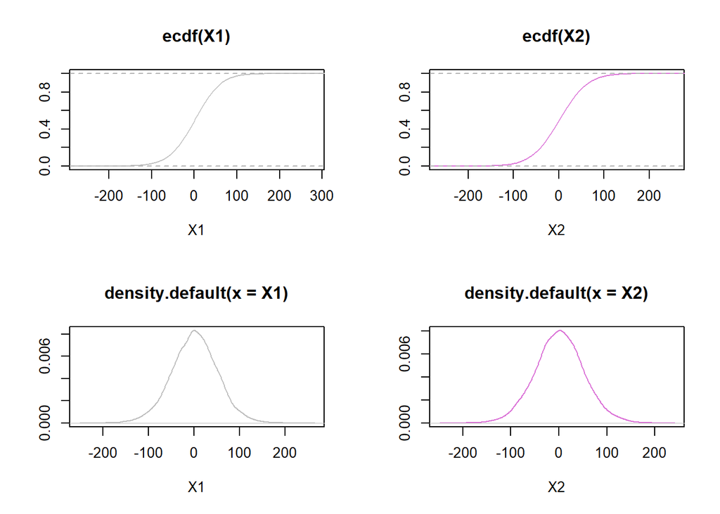

```r
X1 <-joint_dist_sample[,4]  #X1 is put away in the section 4 of an outcome matrix

X2 <-joint_dist_sample[,5]  #X2 is put away in the section 5 of an outcome matrix

#plot ECDF of X1 and X2

par(mfrow = c(2, 2))

plot(ecdf(X1), xlab = "X1", ylab = "", primary = "ECDF X1", col="grey")

plot(ecdf(X2), xlab = "X2", ylab = "", primary = "ECDF X2", col="orchid")

plot(density(X1), xlab = "X1", ylab = "", primary = " Density X1", col="grey")

plot(density(X2), xlab = "X2", ylab = "", primary = "Thickness X2", col="orchid")
```